# Análisis exploratorio

Vamos a explorar el dataset para:

1. Generar preguntas sobre tus datos.
2. Buscar respuestas a estas preguntas.
3. Usar lo aprendido para plantearnos nuevos retos sobre este set de datos.

No hay un guión para hacer estos análisis, sientete libre para incorporar cualquier idea que se te ocurra. El objetivo es entender tus datos y la mejor forma de hacerlo es hacerse muchas preguntas. Es difícil porque de primeras no conoces tus datos pero contestar a estas preguntas te lleva a otras.

## Términos

- **Variables**: Una cantidad, cualidad o propiedad que puedes medir. *Peso*.
- **Valor**: El estado de la variables cuando la mides. *500 gr*.
- **Observación**: Un conjunto de medidas hechas bajo condiciones similares. Una observación puede contener varios valores, cada uno asociado a una variable. *Peso: 500 gr, Altura: 2m*.

Esto es importante para lo que llamamos *tidy data* o *dato limpio*. Puedes leer más sobre esto en un [paper](http://vita.had.co.nz/papers/tidy-data.pdf).

## Cargar paquetes

Primero tenemos que cargar los paquetes que nos serán utiles a lo largo de todo el taller. Si no tenemos instalados los paquetes lo hacemos con la instrucción `install.packages()`. Solo necesitas instalarlo una vez.

Para cargar los paquetes lo hacemos con la instrucción `library()`

```r
library(dplyr)
library(ggplot2)
```

En este caso utilizaremos `dplyr` para transformar los datos y `ggplot2` para visualizarlos.

## Distribuciones

Vamos a ir aprendiendo los comandos a la vez que exploramos el dataset.

La propia librería `ggplot` nos importa unos datasets pequeños y vamos a utilizar uno de ellos para trabajar. El conjunto de datos se llama `diamonds` y contiene precios y otros atributos de unos 50.000 diamantes.

```r
data(diamonds)
```

Si miramos a nuestro entorno podemos ver que ya se nos ha cargado el dataset y se ha quedado almacenado en una variable. Esto no pasa siempre, solo con los set de datos *precargados* en los paquetes de R. Si leyesemos datos de otro sitio tendríamos que almacenarlos en una variable con la asignación `<-`.

#### 1. ¿Cómo podríamos obtener ayuda sobre el dataset?

```r
?diamonds
```

Como visualizamos una variable dependerá si es categórica (*marca*) o continua (*peso*). En este caso vamos a ver la distribución de los cortes de los diamantes:

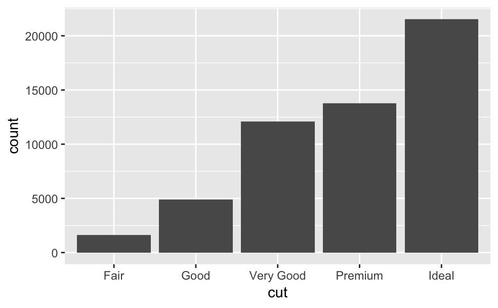

```r
ggplot(data = diamonds) +
  geom_bar(mapping = aes(x = cut))
```

Podemos ver el conteo de las observaciones por corte del diamante (`cut`). Con `ggplot2` empiezas un gráfico llamando a la función `ggplot` y el primer argumento que toma son los datos de los que queremos extraer información. Lo siguiente que vamos haciendo es añadir capas al gráfico, en este caso hemos añadido `geom_bar` que además nos hace el conteo de las observaciones directamente. El argumento `mapping` toma las variables necesarias para pintar el gráfico. Además podríamos añadir otras capas como escalas, colores,…

Con `dplyr` también podemos extraer esta información fácilmente:

```r
diamonds %>%
  count(cut)
```

| cut | n |
| --- | --- |
| Fair | 1610 |
| Good | 4906 |
| Very Good | 12082 |
| Premium | 13791 |
| Ideal | 21551 |

El `%>%` (*pipe*) sirve para concatenar instrucciones: elegimos la variable con la que vamos a tratar (`diamonds`) y sobre esa variable hacemos un conteo (`count`) de la columna `cut`. El pipe coje la información de la iteración anterior:

```r
diamonds %>%
  count(cut) %>%
  arrange(desc(n))
```

| cut | n |
| --- | --- |
| Ideal | 21551 |
| Premium | 13791 |
| Very Good | 12082 |
| Good | 4906 |
| Fair | 1610 |

#### 2. Utiliza geom_histogram para visualizar la variable continua `carat`

Un histograma divide el eje x en partes iguales y utiliza la altura de la barra para mostrar el número de observaciones que caen en esa partición. Puedes utilizar el argumento `binwidth` de `geom_histogram` para cambiar el número de particiones.

A continuación vamos a filtrar los diamantes que tengan menos de 3 quilates.

```r
peques <- diamonds %>%
  filter(carat < 3)

peques
```

| carat | cut | color | clarity | depth | table | price | x | y | z |
| --- | --- | --- | --- | --- | --- | --- | --- | --- | --- |
| 0.23 | Ideal | E | SI2 | 61.5 | 55.0 | 326 | 3.95 | 3.98 | 2.43 |
| 0.21 | Premium | E | SI1 | 59.8 | 61.0 | 326 | 3.89 | 3.84 | 2.31 |
| 0.23 | Good | E | VS1 | 56.9 | 65.0 | 327 | 4.05 | 4.07 | 2.31 |
| 0.29 | Premium | I | VS2 | 62.4 | 58.0 | 334 | 4.20 | 4.23 | 2.63 |
| 0.31 | Good | J | SI2 | 63.3 | 58.0 | 335 | 4.34 | 4.35 | 2.75 |
| 0.24 | Very Good | J | VVS2 | 62.8 | 57.0 | 336 | 3.94 | 3.96 | 2.48 |
| 0.24 | Very Good | I | VVS1 | 62.3 | 57.0 | 336 | 3.95 | 3.98 | 2.47 |
| 0.26 | Very Good | H | SI1 | 61.9 | 55.0 | 337 | 4.07 | 4.11 | 2.53 |
| 0.22 | Fair | E | VS2 | 65.1 | 61.0 | 337 | 3.87 | 3.78 | 2.49 |
| 0.23 | Very Good | H | VS1 | 59.4 | 61.0 | 338 | 4.00 | 4.05 | 2.39 |

[output cut: 990 more lines]

Y visualizarlos por corte:

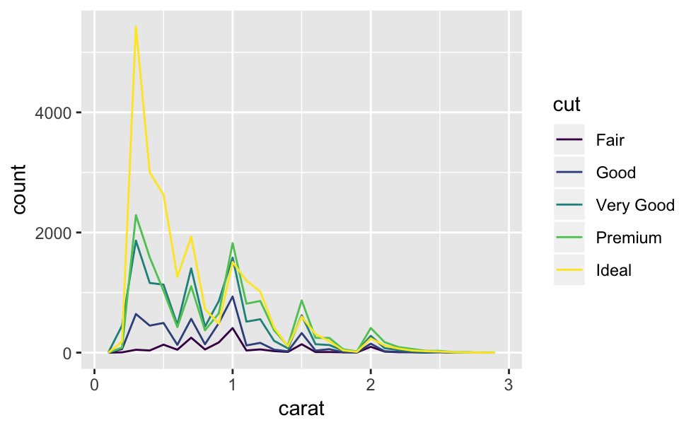

```r
ggplot(data = peques, mapping = aes(x = carat, colour = cut)) +
  geom_freqpoly(binwidth = 0.1)
```

## Explorando los valores

Es muy interesante ver qué valores son los más comunes, los menos, y patrones inusuales. En los quilates, de nuevo, un histograma es lo más interesante:

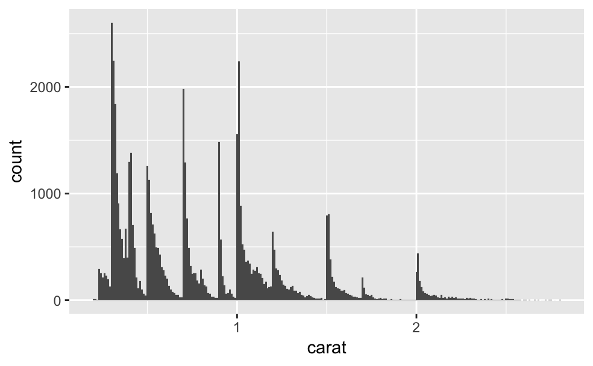

```r
ggplot(data = peques, mapping = aes(x = carat)) +
  geom_histogram(binwidth = 0.01)
```

#### 3. Selecciona con `select` las columnas `x`, `y` y `z` y usa `geom_histogram` y `filter` para encontrar patrones extraños.

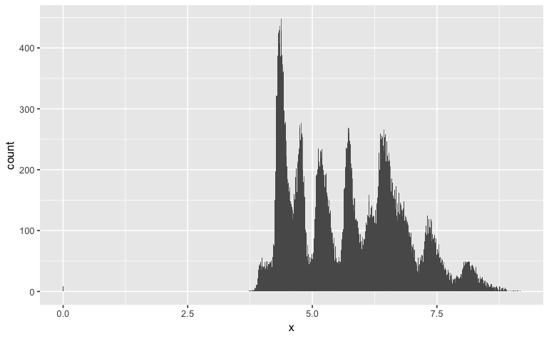

```r
ggplot(data = peques, mapping = aes(x = x)) +
  geom_histogram(binwidth = 0.01)
```

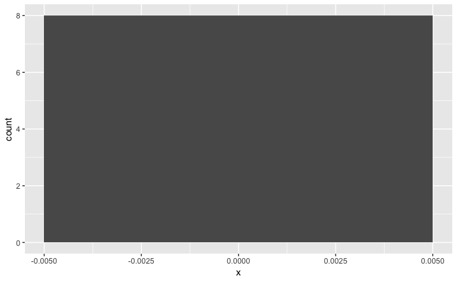

```r
ggplot(data = peques %>% filter(x < 2), mapping = aes(x = x)) +
  geom_histogram(binwidth = 0.01)
```

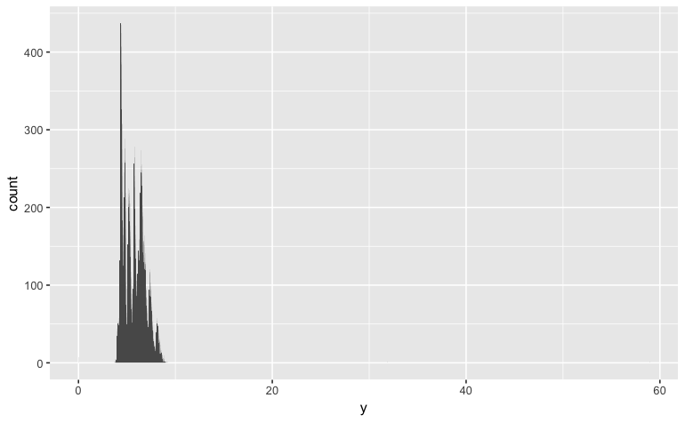

```r
ggplot(data = peques, mapping = aes(x = y)) +
  geom_histogram(binwidth = 0.01)
```

```r
diamonds %>%
  filter(y < 3 | y > 20)
```

| carat | cut | color | clarity | depth | table | price | x | y | z |
| --- | --- | --- | --- | --- | --- | --- | --- | --- | --- |
| 1.00 | Very Good | H | VS2 | 63.3 | 53 | 5139 | 0.00 | 0.0 | 0.00 |
| 1.14 | Fair | G | VS1 | 57.5 | 67 | 6381 | 0.00 | 0.0 | 0.00 |
| 2.00 | Premium | H | SI2 | 58.9 | 57 | 12210 | 8.09 | 58.9 | 8.06 |
| 1.56 | Ideal | G | VS2 | 62.2 | 54 | 12800 | 0.00 | 0.0 | 0.00 |
| 1.20 | Premium | D | VVS1 | 62.1 | 59 | 15686 | 0.00 | 0.0 | 0.00 |
| 2.25 | Premium | H | SI2 | 62.8 | 59 | 18034 | 0.00 | 0.0 | 0.00 |
| 0.51 | Ideal | E | VS1 | 61.8 | 55 | 2075 | 5.15 | 31.8 | 5.12 |
| 0.71 | Good | F | SI2 | 64.1 | 60 | 2130 | 0.00 | 0.0 | 0.00 |
| 0.71 | Good | F | SI2 | 64.1 | 60 | 2130 | 0.00 | 0.0 | 0.00 |

#### 4. Explora la columna `precio`.

## Valores nulos

Si encontramos valores que no tenemos lo más aconsejable antes de deshechar toda la fila es ponerlos como `NA` que significa `Not Available` o `Not Applicable`. Esto nos ayuda a controlar las variables que no son reales y `NA` al ser un tipo de variable del lenguaje está considerado en todas las funciones. Si lo dejasemos como 0, al hacer una media ya nos saldría desvirtuada.

Para modificar una columna nos ayudamos de la función `mutate` y de la función `ifelse` que es igual que la que tiene R implementada pero con una sintaxis más corta.

```r
diamonds_limpio <- diamonds %>%
  mutate(y = ifelse(y < 3 | y > 20, NA, y),
         x = ifelse(x < 2, NA, x))
```

Así tenemos datos más *limpios* y además nos avisan de que hay observaciones que no se están incluyendo en el gráfico porque son `NA`:

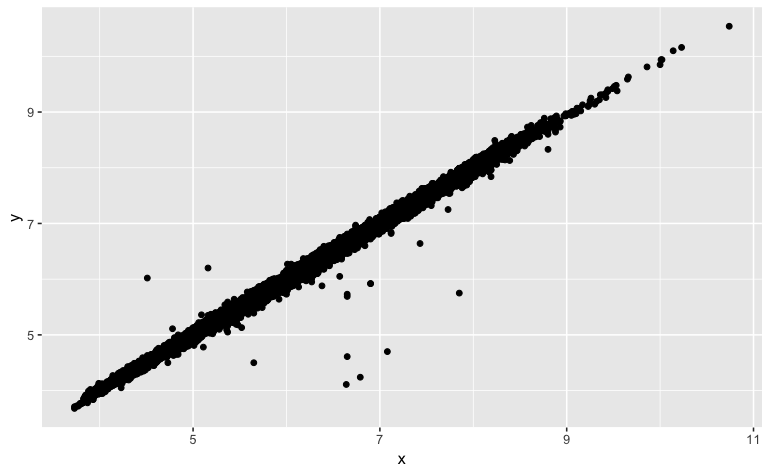

```r
ggplot(data = diamonds_limpio, mapping = aes(x = x, y = y)) +
  geom_point()
```

## Explorando variables categóricas y continuas al mismo tiempo

Hay un tipo de gráfico muy útil para estas ocasiones llamado `boxplot` que nos ayuda a ver la distribución de las variables en nuestro dataset. Cada `boxplot` consiste en:

- una caja que va desde el percentil 25 (valor en el cual están el 25% de observaciones) al 75. En el medio hay una línea que representa la mediana.
- unos puntos que son las observaciones que están fuera de esta caja, a 1.5 del IQR (perc 75 - perc 25) **outliers**
- unas lineas que van desde el final de la caja hasta el primer punto que está fuera pero no es outlier.

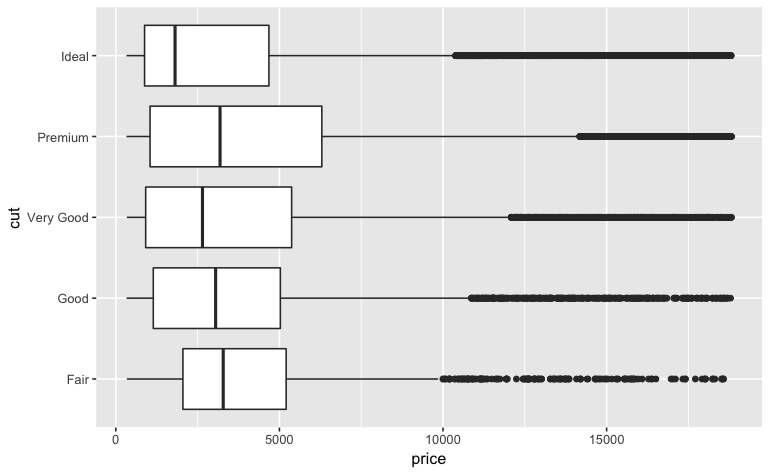

```r
ggplot(data = diamonds_limpio, mapping = aes(x = cut, y = price)) +
  geom_boxplot() +
  coord_flip()
```

#### 5. Con la ayuda utiliza un `geom_violin` para hacer comparar el corte y el precio. ¿Qué diferencia hay con `geom_boxplot`?

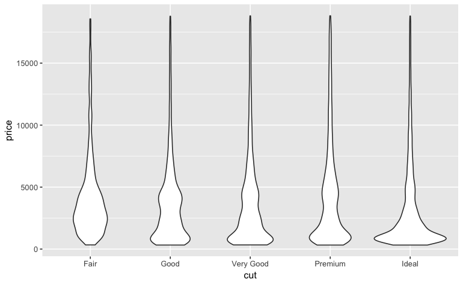

```r
ggplot(data = diamonds_limpio, mapping = aes(x = cut, y = price)) +
  geom_violin()
```

## Variables categóricas

Para visualizar la relación entre dos variables categóricas, necesitamos contar el número de observaciones que se da en la combinación de ambos valores. Lo podemos hacer con `geom_count`. Si miramos la ayuda podemos qué geometría tiene por defecto:

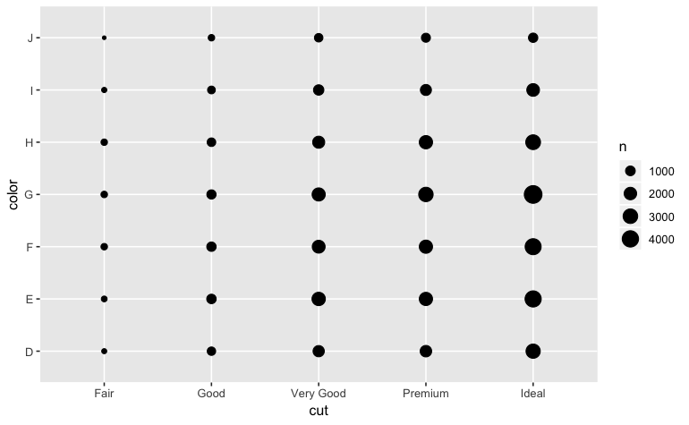

```r
ggplot(data = diamonds_limpio) +
  geom_count(mapping = aes(x = cut, y = color))
```

Cuanto más gordo sea el círculo más observaciones hay bajo esas condiciones. Podemos visualizarlo de otra manera más fácil haciendo el conteo primero y luego ayudándonos de color:

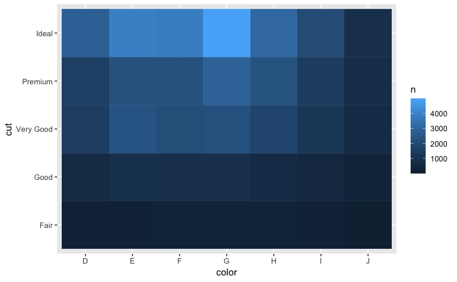

```r
diamonds_limpio %>%
  count(color, cut) %>%
  ggplot(mapping = aes(x = color, y = cut)) +
    geom_tile(mapping = aes(fill = n))
```

## Variables continuas

#### 6. Investiga la relación entre quilates y precio con `geom_point`. Añade también la variable `cut`. ¿Cómo puedes visualizar 3 variables a la vez?

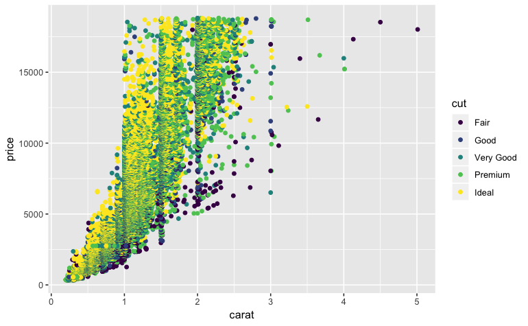

```r
ggplot(data = diamonds) +
  geom_point(mapping = aes(x = carat, y = price, color=cut))
```

Puedes seguir ampliando este tema en [R for DS](http://r4ds.had.co.nz/data-visualisation.html#data-visualisation).